```python
import numpy as np
import pylab as plt
```

# Se define una matriz de $(4x4)$ $x3$ de profundidad

Las capas de profundidad son las que definen el tono final al graficar.

Los valores por cada capa deben estar normalizados entre 0 y 1 para generar el color final, donde 0 es ninguna componente y 1 sería toda la componente de un color.

Una matriz de ceros debe entonces ser de color negro:

```python
COLORES = np.zeros((4,4,3))
```

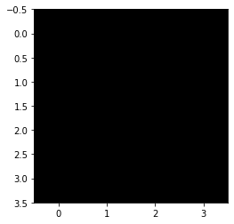

```python
plt.figure()
plt.imshow(COLORES)
```

Si la primera capa (nivel 0 en Python) de la matriz COLORES se establece como 1, entonces el color ROJO representado por esa capa será total y no tendrá ningún otro color, ya que la capa 1 y 2 siguen teniendo valores de 0.

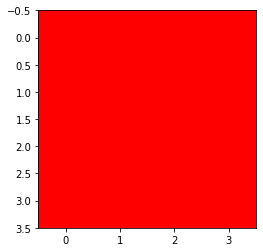

```python
COLORES = np.zeros((4,4,3))
COLORES[:,:,0]=1
plt.figure()
plt.imshow(COLORES)
```

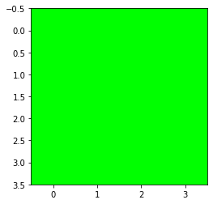

```python
COLORES = np.zeros((4,4,3))
COLORES[:,:,1]=1
plt.figure()
plt.imshow(COLORES)
```

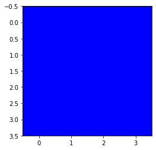

```python
COLORES = np.zeros((4,4,3))
COLORES[:,:,2]=1
plt.figure()
plt.imshow(COLORES)
```

# Se pueden combinar diferentes valores en las capas para generar diferentes colores:

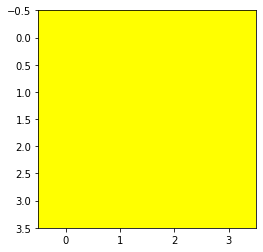

```python
COLORES = np.zeros((4,4,3))
COLORES[:,:,0]=1
COLORES[:,:,1]=1
COLORES[:,:,2]=0
plt.figure()
plt.imshow(COLORES)
```

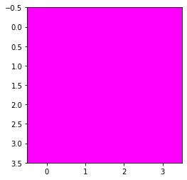

```python
COLORES = np.zeros((4,4,3))
COLORES[:,:,0]=1
COLORES[:,:,1]=0
COLORES[:,:,2]=1
plt.figure()
plt.imshow(COLORES)
```

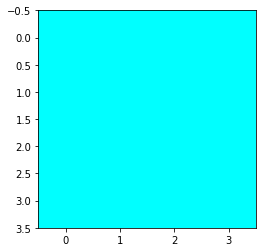

```python
COLORES = np.zeros((4,4,3))
COLORES[:,:,0]=0
COLORES[:,:,1]=1
COLORES[:,:,2]=1
plt.figure()
plt.imshow(COLORES)
```

# Todas las capas con valores de 1 signigicaría que la matriz tiene cada punto con todo el rojo, todo el verde y todo el azul.

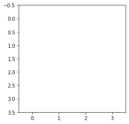

```python
COLORES = np.zeros((4,4,3))
COLORES[:,:,0]=1
COLORES[:,:,1]=1
COLORES[:,:,2]=1
plt.figure()
plt.imshow(COLORES)
```

# Los colores se pueden establecer de manera individual.

**Es en este punto donde las mediciones satelitales permiten asignar a cada punto de una imagen el valor correspondiente observado por los sensores.**

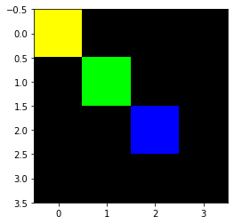

```python
COLORES = np.zeros((4,4,3))
COLORES[1,1,1]=1
COLORES[0,0,0]=1
COLORES[0,0,1]=1
COLORES[2,2,2]=1
plt.figure()
plt.imshow(COLORES)
```

# Haciendo un RGB simple con datos del GOES 16

```python
pip install netcdf4
```

```python
!wget -c https://noaa-goes16.s3.amazonaws.com/ABI-L2-CMIPF/2021/104/16/OR_ABI-L2-CMIPF-M6C01_G16_s20211041630185_e20211041639493_c20211041639567.nc
!wget -c https://noaa-goes16.s3.amazonaws.com/ABI-L2-CMIPF/2021/104/16/OR_ABI-L2-CMIPF-M6C02_G16_s20211041630185_e20211041639493_c20211041639565.nc
!wget -c https://noaa-goes16.s3.amazonaws.com/ABI-L2-CMIPF/2021/104/16/OR_ABI-L2-CMIPF-M6C03_G16_s20211041630185_e20211041639493_c20211041639567.nc
```

```
--2021-04-14 16:55:49--  https://noaa-goes16.s3.amazonaws.com/ABI-L2-CMIPF/2021/104/16/OR_ABI-L2-CMIPF-M6C01_G16_s20211041630185_e20211041639493_c20211041639567.nc
Resolving noaa-goes16.s3.amazonaws.com (noaa-goes16.s3.amazonaws.com)... 52.216.81.216
Connecting to noaa-goes16.s3.amazonaws.com (noaa-goes16.s3.amazonaws.com)|52.216.81.216|:443... connected.
HTTP request sent, awaiting response... 416 Requested Range Not Satisfiable

    The file is already fully retrieved; nothing to do.

--2021-04-14 16:55:49--  https://noaa-goes16.s3.amazonaws.com/ABI-L2-CMIPF/2021/104/16/OR_ABI-L2-CMIPF-M6C02_G16_s20211041630185_e20211041639493_c20211041639565.nc
Resolving noaa-goes16.s3.amazonaws.com (noaa-goes16.s3.amazonaws.com)... 52.216.81.216
Connecting to noaa-goes16.s3.amazonaws.com (noaa-goes16.s3.amazonaws.com)|52.216.81.216|:443... connected.
HTTP request sent, awaiting response... 416 Requested Range Not Satisfiable

    The file is already fully retrieved; nothing to do.

--2021-04-14 16:55:49--  https://noaa-goes16.s3.amazonaws.com/ABI-L2-CMIPF/2021/104/16/OR_ABI-L2-CMIPF-M6C03_G16_s20211041630185_e20211041639493_c20211041639567.nc
Resolving noaa-goes16.s3.amazonaws.com (noaa-goes16.s3.amazonaws.com)... 52.216.81.216
Connecting to noaa-goes16.s3.amazonaws.com (noaa-goes16.s3.amazonaws.com)|52.216.81.216|:443... connected.
HTTP request sent, awaiting response... 416 Requested Range Not Satisfiable

    The file is already fully retrieved; nothing to do.
```

```python
from netCDF4 import Dataset
C1 = Dataset('OR_ABI-L2-CMIPF-M6C01_G16_s20211041630185_e20211041639493_c20211041639567.nc')
C2 = Dataset('OR_ABI-L2-CMIPF-M6C02_G16_s20211041630185_e20211041639493_c20211041639565.nc')
C3 = Dataset('OR_ABI-L2-CMIPF-M6C03_G16_s20211041630185_e20211041639493_c20211041639567.nc')
```

```python
ROJO = C2.variables['CMI'][:][::8,::8]
VERDE = C3.variables['CMI'][::4,::4]
AZUL = C1.variables['CMI'][::4,::4]
```

```python
np.max(ROJO)
```

```
1.2190465
```

```python
np.shape(ROJO), np.shape(VERDE), np.shape(AZUL)
```

```
((2712, 2712), (2712, 2712), (2712, 2712))
```

```python
ROJO = (ROJO - ROJO.min()) / (ROJO.max() - ROJO.min())
VERDE = (VERDE - VERDE.min()) / (VERDE.max() - VERDE.min())
AZUL = (AZUL - AZUL.min()) / (AZUL.max() - AZUL.min())
```

```python
COLORES = np.zeros((2712,2712,3))
```

```python
COLORES[:,:,0] = ROJO
COLORES[:,:,1] = VERDE
COLORES[:,:,2] = AZUL
```

```
Clipping input data to the valid range for imshow with RGB data ([0..1] for floats or [0..255] for integers).
```

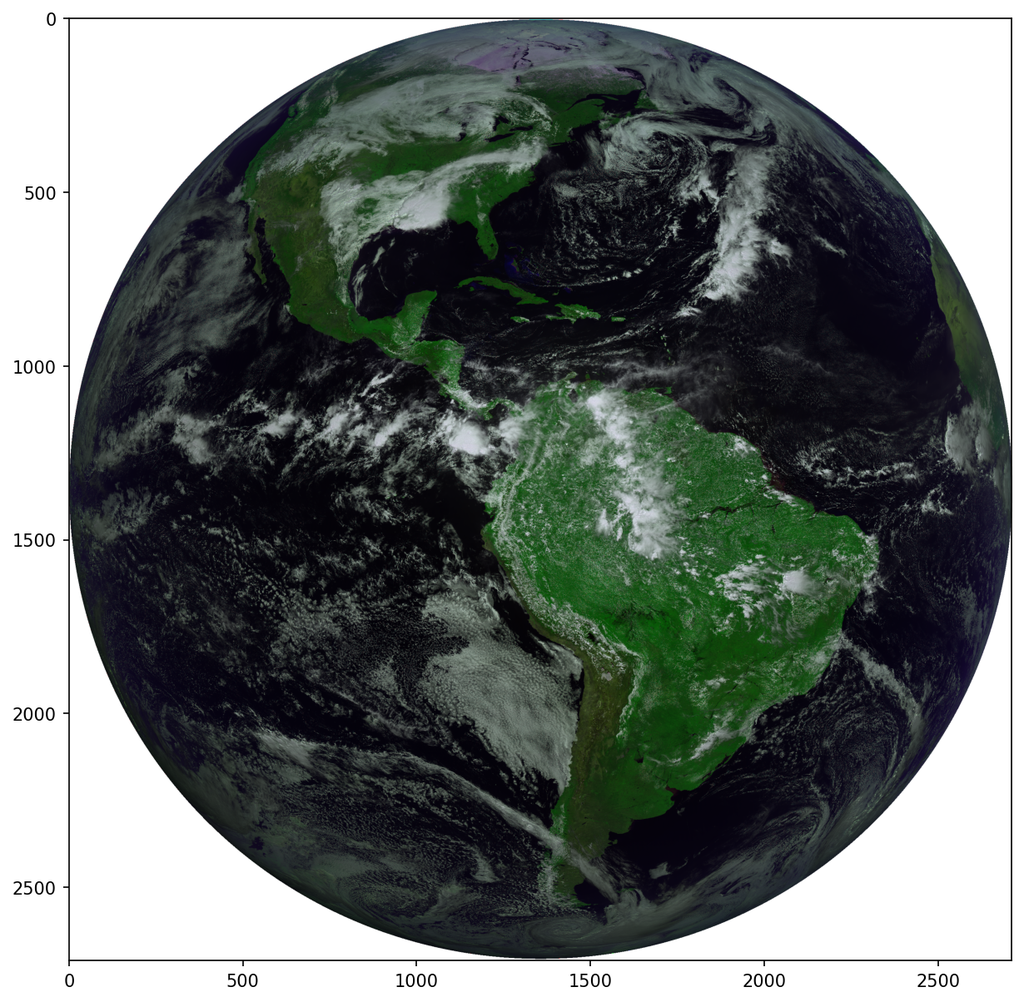

```python
plt.figure(figsize = (10,10),dpi=150)
plt.imshow(COLORES)
```